# Predicting Visibility in Ocean Water From Buoy Data

## What

My goal of this project is to see if I can use buoy data from off the Santa Barbara Coast to predict water visibility of the ocean water about fourty meters off of campus point.

## Why

For as long as I can remember I have always loved diving. What I don't love is getting 40 meters out into the water and realizing that I can't even see my feet in the water. When this happened to me, I tried looking up what causes bad water visibility, and I kept getting different answers. Some people said it was the amount of chlorophyll in the water but the day I went out the levels were very low and I have seen multiple time when high chlorophyll days had great visibilitt. I then decided that I was going to try and find a way to predict the water visibility before I got out there.

## How

Predicting Water Visibility has been a difficult problem for many people. Almost no buoys and no satelittes measure water visibility directly making it really hard to do any machine learning to predict the visibility. Luckily there is a paper by Keivan Kabiri and Masoud Moradi (citiation at the bottom) that attempts to use the Landsat-8 measured "band values" to predict water visibility. They came up with the equation: $$ SDD = 0.077*e^{1.209B1 - 1.739B2 + 0.412B3 - 5.198(B3/B1) + 10.408(B2/B1)}$$ I use the above equation is a formula for the SDD or Secchi disk depth. This depth is the depth of a Secchi disk before a viewer can no longer see the disk. I will be using this formula as my response variable

For my predictor variables I use the Station 46054 (LLNR 198.1) - WEST SANTA BARBARA 38 NM West of Santa Barbara, CA Buoy. I use the buoy's Standard meteorological data.

## TOC:

- Data Gathering
  - Example of How I Gathered Band Data
  - Actually Gathering Band Data
  - Gathering Predictor variables
- Data Manipulation
- Data Exploratory Analysis
  - Predictor Variables Analysis
  - Response Variable Analysis
- Machine Learning
  - Linear Regression Model
  - Lasso Regression Model
  - Elastic Net Regression Model
  - Decision Tree Regression Model
  - Polynomial Regression Model
  - Best_Model
- Conclusion
- Citations

## Data Gathering

### Example of How I Gathered Band Data

```python
#Importing Necessary Packages
import numpy as np
from PIL import Image
import math
import cv2
import matplotlib.pyplot as plt
from pylab import *
```

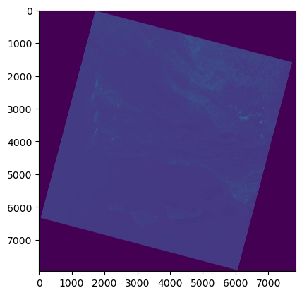

```python
#Import Image
img = Image.open('/Users/jakebentley/Desktop/LandsatTest/20230209/20230209_20230217_02_B1.TIF')
plt.imshow(img)
```

We need to crop the image so that we are just looking at Isla Vista Coast.

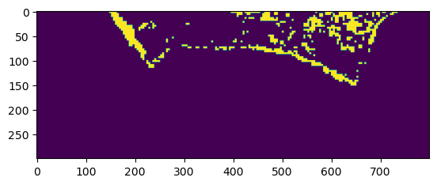

```python
#Creates a box around isla vista
box = (3900,4700,4100,4775)
#Crops image into the box
region1 = img.crop(box)
#Resizes Image so we get a nice output
img = region1.resize((800,300))

#Turns image into a numpy array so it is easier to work with
img = np.asarray(img)

#We are now thresholding the image so that we can see all values above 11100
#Outputs an array of true or falses. I true means yellow and false means blue
binary_min = img > 10000

#This shows the image we are now working with
plt.imshow(binary_min)
```

Now we want to extract the point about 40 meters away from campus point. It is ok if it is not exact since we are more concerned with the visibility of the 'area' off of campus point

```
Last row with a True value: 151
Last column with a True value: 651
Value of Band: 8081
```

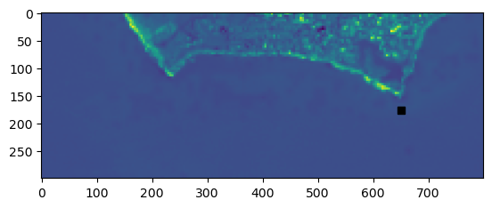

```python
#These two for loops are going to get us the position of the "point" that is campus point
#Finds the farthest down row with true value
for i in range(len(binary_min)-1, -1, -1):
    if True in binary_min[i]:
        last_row_with_true = i
        break

#For the row it finds that farthest right true value
for i in range(len(binary_min[:][1])-1, -1, -1):
    if binary_min[last_row_with_true][i] == True:
        last_column_with_true = i
        break


print("Last row with a True value:", last_row_with_true)
print("Last column with a True value:", last_column_with_true)
plt.imshow(img)
plot(last_column_with_true,last_row_with_true + 25,'ks')

#We now get that we were after: the value of the band
print("Value of Band:", img[last_row_with_true + 25][last_column_with_true])
```

### Actually Gathering Band Data

```python
#Import packages
import os
import pandas as pd
```

First we need to gather all the images from the folder in which I downloaded them all. We will put the images in a dictionary where the keys are the dates that this image was taken

```python
def GetImagesFromFolder(directory, band_number,n_images = 4):


    #This collects all the subfolders which contain 4 images each. These images are the band values for each
    #Satelitte
    sub_folders = [name for name in os.listdir(directory) if os.path.isdir(os.path.join(directory, name))]

    # Creating an empty dictionary
    imagesDict = {}

    #For each subfolder we are going to exact the 4 images individually
    for items in sub_folders:

        #Creates new directory that goes directly to one image
        new_directory = directory + "/" + items

        count = 0

        #List that will hold our files
        listfiles = []

        #This for loop just imports all the files for all the images
        for filename in os.listdir(new_directory):

            f = os.path.join(new_directory, filename)
            # checking if it is a TIF file and checks if file is the correct band number
            if os.path.isfile(f) and count < n_images and 'B' + str(band_number) + '.TIF' == f[len(f) - 6:]:
                count += 1
                listfiles.append(f)


        #Adding list as value
        imagesDict[items] = listfiles

    return imagesDict
```

This code essentially does exactly what our example does

```python
def deriveBandValue(directory,n):

    #We use function about to get images
    imageDict = GetImagesFromFolder(directory,n)

    imglist = []
    dateList = []

    #Puts the dates into a nice readable format
    for keys in imageDict.keys():

        imglist.append(Image.open(imageDict[keys][0]))

        dateList.append(keys[ 0 : 4 ] + '-' + keys[4:6] + '-' + keys[6:8])

    # Create the pandas DataFrame with column name is provided explicitly
    df = pd.DataFrame(dateList, columns=['Date'])


    box = (3700,4700,4080,4765)

    valueList = []

    for x in range(len(imglist)):

        region1 = imglist[x].crop(box)
        imglist[x] = region1.resize((400,65))

        #Turn image into an array
        img1 = array(imglist[x])

        #Threshold Image
        binary_min = img1 > 11000

        for i in range(len(binary_min)-1, -1, -1):
            if True in binary_min[i]:
                last_row_with_true = i
                break

        for i in range(len(binary_min[:][1])-1, -1, -1):
            if binary_min[last_row_with_true][i] == True:
                last_column_with_true = i
                break


        value = img1[last_row_with_true + 7][last_column_with_true]


        valueList.append(value)

    #Labels the dataframe column "Band n"
    df['Band' + str(n)] = valueList


    return valueList, df

    #print(GetBandValue(img))
```

Here we use the above function to create a dataframe with all the band values we need

```python
#Get first band value of all images
valueList , df = deriveBandValue('/Users/jakebentley/Desktop/LandsatTest',1)

#Gets second band value of all images
valueList2 , df_notused = deriveBandValue('/Users/jakebentley/Desktop/LandsatTest',2)

#Get third band value of all images
valueList3 , df_notused = deriveBandValue('/Users/jakebentley/Desktop/LandsatTest',3)

#Adds band values 2 and 3 to dataframe that already contains band 1 value
df['Band 2'] = valueList2
df['Band 3'] = valueList3

#shows us the dataframe we want to work with
print(df)
```

```
          Date  Band1  Band 2  Band 3
0   2014-01-15   7936    8011    8179
1   2021-11-02   8012    7990    8170
2   2017-03-28   7488    7718    7863
3   2016-10-03   7663    7805    7825
4   2019-10-12   7338    7504    7753
..         ...    ...     ...     ...
71  2019-03-18   7626    7831    8037
72  2023-02-09   8038    8234    8027
73  2020-11-15   8002    8015    8097
74  2020-02-01   8316    8481    8519
75  2016-03-09   7653    8149    8277

[76 rows x 4 columns]
```

Here we are using the papers formula in order to get an estimates SDD.

```python
#Initiates a list
SDDlist = []

for i in range(len(df['Date'])):
    #We do this since this puts the bands into a form that the paper uses
    b1 = df['Band1'][i] * (1 / 65535) - 0.2
    b2 = df['Band 2'][i] * (1 / 65535) - 0.2
    b3 = df['Band 3'][i] * (1 / 65535) - 0.2

    #Function that is in cited paper
    SDD = 0.077 * np.exp((1.209 * b1) - (1.739 * b2) + (0.412 * b3) - (5.198 * (b3/b1)) + (10.408 * (b2/b1)))

    #Adds SDD value to a list
    SDDlist.append(SDD)

#Adds a SDD column
df['SDD'] = SDDlist

#Changes the dataframe so we just have data and SDD value
df = df[['Date','SDD']]
print(df)
```

```
          Date        SDD
0   2014-01-15  15.614655
1   2021-11-02  17.512879
2   2017-03-28  13.109003
3   2016-10-03  12.632877
4   2019-10-12  15.318807
..         ...        ...
71  2019-03-18  14.204555
72  2023-02-09   9.357585
73  2020-11-15  15.267414
74  2020-02-01  12.346498
75  2016-03-09   9.922587

[76 rows x 2 columns]
```

Now we have our response variable

### Gathering Predictor variables

This will be much easier than the response variable

The read_table function was having hard time reading the buoy data that was a txt file so I had to do some manipulation to get the data into a workable formate

```python
#Reads in buoy data for a given year
dataWhole = []
count = 0
for X in [2013,2014,2015,2016,2017,2018,2019,2020,2021,2022]:

    #Creates a directory for each year of the buoy data and reads it in
    direct = '/Users/jakebentley/buoyData' + str(X) + '.txt'
    data = pd.read_table(direct, delimiter = None)

    Date = []
    hh = []
    mm = []
    WDIR = []
    WSPD = []
    GST = []
    WVHT = []
    DPD = []
    APD = []
    MWD = []
    PRES = []
    ATMP = []
    WTMP = []
    DEWP = []

    #Takes the column name that read_table gives
    for i in range(1,len(data)):
        dataList = data['#YY  MM DD hh mm WDIR WSPD GST  WVHT   DPD   APD MWD   PRES  ATMP  WTMP  DEWP  VIS  TIDE'][i].split(" ")
        #Gets rid of spaces
        dataList = [value for value in dataList if value != '']
        #Extracts all elements
        Date.append(dataList[0] + "-" + dataList[1] + "-" + dataList[2])
        hh.append(dataList[3])
        mm.append(dataList[4])
        WDIR.append(float(dataList[5]))
        WSPD.append(float(dataList[6]))
        GST.append(float(dataList[7]))
        WVHT.append(float(dataList[8]))
        DPD.append(float(dataList[9]))
        APD.append(float(dataList[10]))
        MWD.append(float(dataList[11]))
        PRES.append(float(dataList[12]))
        ATMP.append(float(dataList[13]))
        WTMP.append(float(dataList[14]))
        DEWP.append(float(dataList[15]))

    #Creates a dataframe for each year
    weatherDF = pd.DataFrame(Date, columns=['Date'])
    weatherDF['hh'] = hh
    weatherDF['mm'] = mm
    weatherDF['WDIR'] = WDIR
    weatherDF['WSPD'] = WSPD
    weatherDF['GST'] = GST
    weatherDF['WVHT'] = WVHT
    weatherDF['DPD'] = DPD
    weatherDF['APD'] = APD
    weatherDF['MWD'] = MWD
    weatherDF['PRES'] = PRES
    weatherDF['ATMP'] = ATMP
    weatherDF['WTMP'] = WTMP
    weatherDF['DEWP'] = DEWP

    #Adds a dataframe as an element to a list
    dataWhole.append(weatherDF)
```

Concatinate the list so that we have a dataframe

```python
weatherDF = pd.concat(dataWhole)
print(weatherDF)
```

```
             Date  hh  mm   WDIR  WSPD  GST   WVHT    DPD    APD    MWD  \
0      2012-12-31  23  50  290.0   3.2  4.1   1.03   8.33   6.90  276.0
1      2013-01-01  00  50  281.0   2.6  3.3   1.04  12.90   6.46  269.0
2      2013-01-01  01  50  303.0   2.0  2.5  99.00  99.00  99.00  999.0
3      2013-01-01  02  50  287.0   3.0  3.6   1.00  19.05   6.53   78.0
4      2013-01-01  03  50  300.0   1.6  2.4   1.03  19.05   6.78  189.0
...           ...  ..  ..    ...   ...  ...    ...    ...    ...    ...
52475  2022-12-31  23  10  156.0   2.4  3.5   1.32  12.12   7.43  268.0
52476  2022-12-31  23  20  162.0   2.3  3.2  99.00  99.00  99.00  999.0
52477  2022-12-31  23  30  157.0   2.0  3.1  99.00  99.00  99.00  999.0
52478  2022-12-31  23  40  163.0   2.9  4.5   1.39  12.12   7.57  270.0
52479  2022-12-31  23  50  176.0   3.9  4.9  99.00  99.00  99.00  999.0

         PRES  ATMP  WTMP   DEWP
0      1023.0  12.9  14.0  999.0
1      1022.7  12.6  14.1  999.0
2      1022.7  12.6  14.0  999.0
3      1023.3  12.8  13.8  999.0
4      1023.5  12.9  13.7  999.0
...       ...   ...   ...    ...
52475  1011.7  15.0  14.8  999.0
52476  1011.6  15.0  14.8  999.0
52477  1011.4  15.0  14.8  999.0
52478  1011.2  15.2  14.7  999.0
52479  1011.1  15.5  14.7  999.0

[414417 rows x 14 columns]
```

Now we have all the data for our response variable and all the data for out predictor variables

## Data Manipulation

### We only want buoy data that was taken at the same time as the satelitte images were taken

Filter out data that wasn't taken at the same date as the satelitte

```python
#Filter for date that matches df date
weatherDF = weatherDF[weatherDF["Date"].isin(list(df["Date"]))]
```

```python
#Luckily we know that the satellite took picuters at around 18:40 or 50 UTC
#Filters for hour and minute that matches 18:40/50
weatherDF = weatherDF[weatherDF["hh"].isin(['18'])]
weatherDF = weatherDF[weatherDF["mm"].isin(['40','50'])]
weatherDF = weatherDF[weatherDF.WVHT != 99.00]
```

We now merge our response and predictor variables on date

```python
#We use the pandas merge function
ProjectData = pd.merge(df[['Date','SDD']], weatherDF, on="Date")
```

We want to add one more thing. That is time of the year. Which I have heard affects the visibility

```python
seasonList = []

#Takes the date and outputs which time of the year it is in
for index, row in ProjectData.iterrows():
    #month = row['Data']
    if row['Date'][5:7] in ["12","01","02"]:
        #If date of row is during winter add winter to the row
        seasonList.append('Winter')

    if row['Date'][5:7] in ["03","04","05"]:
        seasonList.append('Spring')

    if row['Date'][5:7] in ["06","07","08"]:
        seasonList.append('Summer')

    if row['Date'][5:7] in ["09","10","11"]:

        seasonList.append('Fall')


#Adds the list of seasons to the data fram
ProjectData["Season"] = seasonList
ProjectData
```

|  | Date | SDD | hh | mm | WDIR | WSPD | GST | WVHT | DPD | APD | MWD | PRES | ATMP | WTMP | DEWP | Season |
| --- | --- | --- | --- | --- | --- | --- | --- | --- | --- | --- | --- | --- | --- | --- | --- | --- |
| 0 | 2014-01-15 | 15.614655 | 18 | 50 | 23.0 | 1.8 | 2.0 | 0.87 | 12.12 | 8.06 | 263.0 | 1024.1 | 16.6 | 15.0 | 999.0 | Winter |
| 1 | 2021-11-02 | 17.512879 | 18 | 40 | 99.0 | 1.4 | 2.5 | 1.59 | 13.79 | 9.28 | 278.0 | 1022.5 | 15.7 | 16.7 | 13.4 | Fall |
| 2 | 2016-10-03 | 12.632877 | 18 | 50 | 290.0 | 7.5 | 8.9 | 1.18 | 6.25 | 4.63 | 261.0 | 1016.9 | 999.0 | 999.0 | 999.0 | Fall |
| 3 | 2019-10-12 | 15.318807 | 18 | 40 | 262.0 | 0.1 | 0.6 | 0.42 | 7.69 | 5.61 | 271.0 | 1012.1 | 19.3 | 17.8 | 15.0 | Fall |
| 4 | 2018-12-28 | 10.809154 | 18 | 40 | 113.0 | 1.7 | 2.7 | 1.32 | 10.00 | 6.19 | 262.0 | 1021.3 | 13.7 | 15.5 | 3.2 | Winter |
| ... | ... | ... | ... | ... | ... | ... | ... | ... | ... | ... | ... | ... | ... | ... | ... | ... |
| 60 | 2017-10-22 | 15.268048 | 18 | 40 | 251.0 | 1.4 | 2.2 | 1.50 | 13.79 | 7.39 | 265.0 | 1021.0 | 17.1 | 17.2 | 15.4 | Fall |
| 61 | 2019-03-18 | 14.204555 | 18 | 40 | 260.0 | 1.2 | 2.0 | 1.29 | 14.81 | 9.50 | 247.0 | 1016.8 | 14.5 | 14.0 | 13.9 | Spring |
| 62 | 2020-11-15 | 15.267414 | 18 | 40 | 239.0 | 1.9 | 2.8 | 1.55 | 12.90 | 7.29 | 274.0 | 1021.3 | 15.3 | 15.0 | 13.2 | Fall |
| 63 | 2020-02-01 | 12.346498 | 18 | 40 | 322.0 | 1.1 | 1.5 | 1.22 | 12.90 | 9.08 | 257.0 | 1024.8 | 15.9 | 14.6 | 15.2 | Winter |
| 64 | 2016-03-09 | 9.922587 | 18 | 50 | 277.0 | 7.3 | 9.7 | 1.98 | 11.43 | 6.21 | 259.0 | 1017.5 | 15.5 | 14.6 | 11.4 | Spring |

65 rows × 16 columns

Now we have our data that we want to work with for the project

## Data Exploratory Analysis

```python
#For Missing Data
import missingno as msno

#For correlation heatmap
import seaborn as sb

#Gets rid of warnings
import warnings; warnings.simplefilter('ignore')
```

First we want to look at the Data information

```python
ProjectData.info()
```

```
<class 'pandas.core.frame.DataFrame'>
Int64Index: 65 entries, 0 to 64
Data columns (total 16 columns):
 #   Column  Non-Null Count  Dtype
---  ------  --------------  -----
 0   Date    65 non-null     object
 1   SDD     65 non-null     float64
 2   hh      65 non-null     object
 3   mm      65 non-null     object
 4   WDIR    65 non-null     float64
 5   WSPD    65 non-null     float64
 6   GST     65 non-null     float64
 7   WVHT    65 non-null     float64
 8   DPD     65 non-null     float64
 9   APD     65 non-null     float64
 10  MWD     65 non-null     float64
 11  PRES    65 non-null     float64
 12  ATMP    65 non-null     float64
 13  WTMP    65 non-null     float64
 14  DEWP    65 non-null     float64
 15  Season  65 non-null     object
dtypes: float64(12), object(4)
memory usage: 8.6+ KB
```

First column of data is just the index so we want to not select that. Also since we made sure that all measurements were taken at the same time of day we actually don't need them in our dataset anymore. We also want to transform any catergorical variables.

```python
#Change ProjectData to data so it is faster to type
data = ProjectData

data = data.loc[:, data.columns != "Unnamed: 0"]
data = data.loc[:, data.columns != "hh"]
data = data.loc[:, data.columns != "mm"]
data = data.loc[:, data.columns != "Date"]

data = pd.get_dummies(data)

#We don't want linearly dependent response variables so we get rid of Fall becaus it is fully
#described by the other season columns
data = data.loc[:, data.columns != "Season_Fall"]
data.head()
```

|  | SDD | WDIR | WSPD | GST | WVHT | DPD | APD | MWD | PRES | ATMP | WTMP | DEWP | Season_Spring | Season_Summer | Season_Winter |
| --- | --- | --- | --- | --- | --- | --- | --- | --- | --- | --- | --- | --- | --- | --- | --- |
| 0 | 15.614655 | 23.0 | 1.8 | 2.0 | 0.87 | 12.12 | 8.06 | 263.0 | 1024.1 | 16.6 | 15.0 | 999.0 | 0 | 0 | 1 |
| 1 | 17.512879 | 99.0 | 1.4 | 2.5 | 1.59 | 13.79 | 9.28 | 278.0 | 1022.5 | 15.7 | 16.7 | 13.4 | 0 | 0 | 0 |
| 2 | 12.632877 | 290.0 | 7.5 | 8.9 | 1.18 | 6.25 | 4.63 | 261.0 | 1016.9 | 999.0 | 999.0 | 999.0 | 0 | 0 | 0 |
| 3 | 15.318807 | 262.0 | 0.1 | 0.6 | 0.42 | 7.69 | 5.61 | 271.0 | 1012.1 | 19.3 | 17.8 | 15.0 | 0 | 0 | 0 |
| 4 | 10.809154 | 113.0 | 1.7 | 2.7 | 1.32 | 10.00 | 6.19 | 262.0 | 1021.3 | 13.7 | 15.5 | 3.2 | 0 | 0 | 1 |

Will replace 999.0, 9999.0, and 99.0 values (which are how the data was marked as and NaN in dataframe) with value nan so our function can reconize that its missing. Then we can plot the missing values

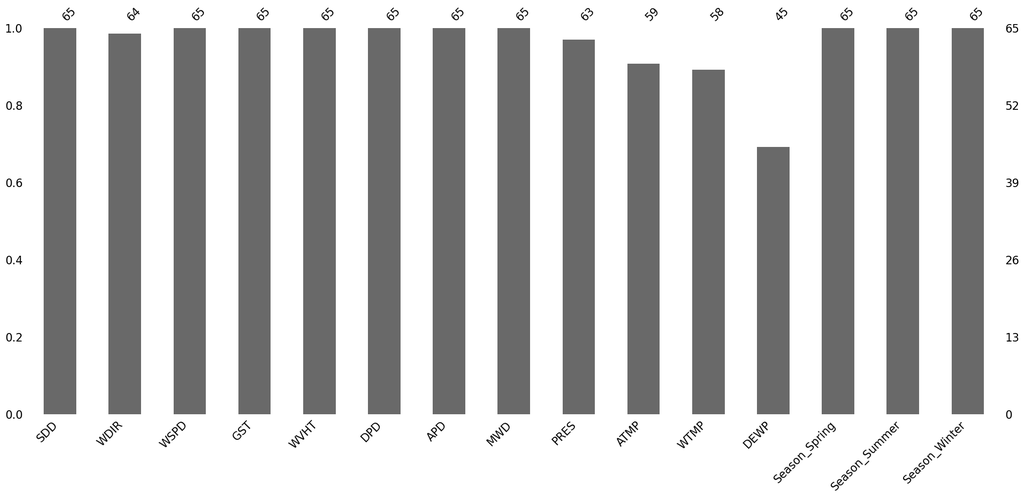

```python
#Replaces each null value with a Nan
data = data.replace(to_replace = 9999.0, value = np.nan)
data = data.replace(to_replace = 999.0, value = np.nan)
data = data.replace(to_replace = 99.0, value = np.nan)

#Missing value bar graph
msno.bar(data)
```

We have limited data so we don't want to get rid of any rows. Thus we just replace NaNs with the mean of the column

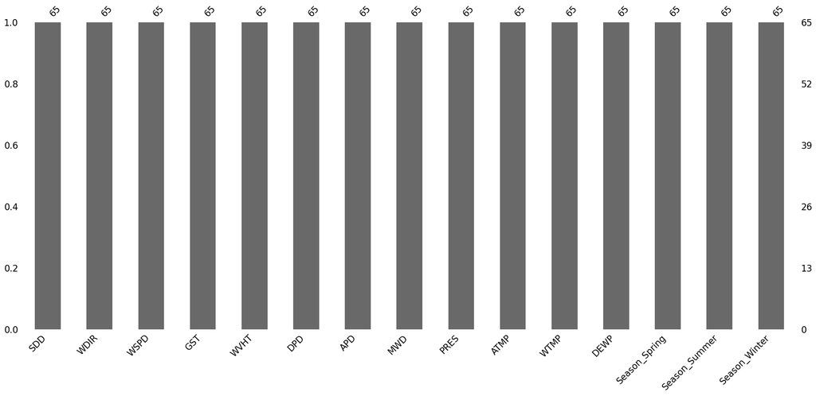

```python
#Replaces each column with the column mean
data.DEWP = data.DEWP.fillna(round(data.DEWP.mean(),2))
data.WTMP = data.WTMP.fillna(round(data.WTMP.mean(),2))
data.ATMP = data.ATMP.fillna(round(data.ATMP.mean(),2))
data.PRES = data.PRES.fillna(round(data.PRES.mean(),2))
data.WDIR = data.WDIR.fillna(round(data.WDIR.mean(),2))

#Makes sure we now don't have any missing values
msno.bar(data)
```

We want to now seperate our Response from the Predictors

```python
X = data[list(data.columns[1:15])]
SDD = data[[data.columns[0]]]
```

### Now we can do some analysis on our predictor variables

I am a fan of the graph because it helps shows you if there are any outliers and it also shows the distribution of the graph

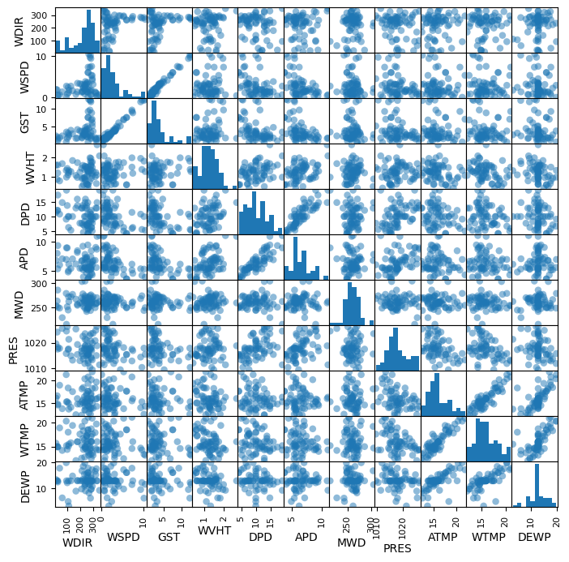

```python
_ = pd.plotting.scatter_matrix(X[list(X.columns[0:11])], figsize = [8, 8], s=150)
```

It appears GST and WSPD are closley correlated as well as ATMP and WTMP. Lets take a closer look.

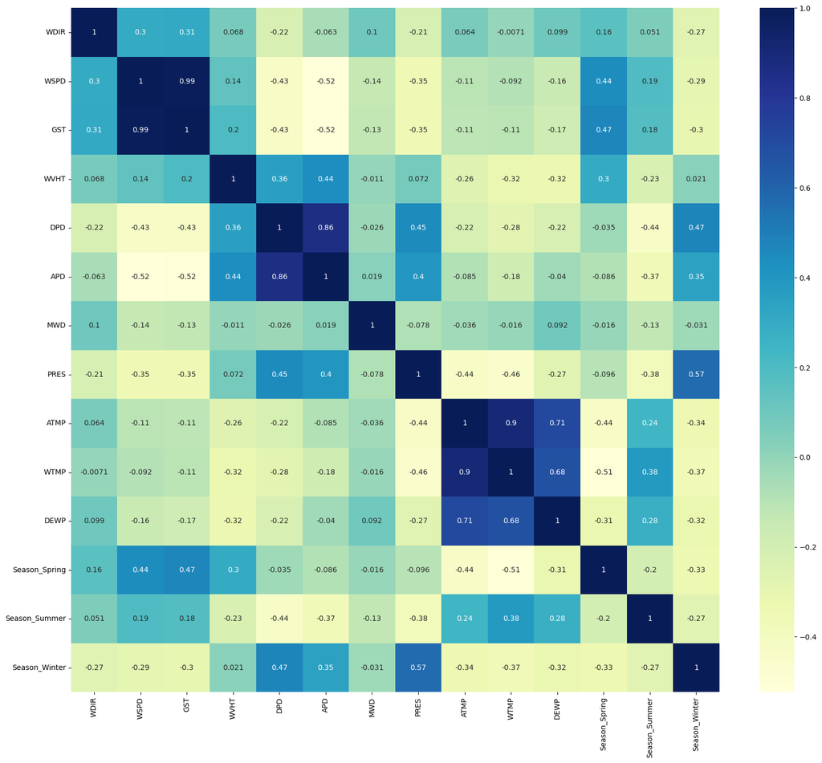

```python
#Sets size of image
plt.figure(figsize = (20, 17))

#creates head map
dataplot = sb.heatmap(X.corr(), annot = True, cmap="YlGnBu")

# displaying heatmap
plt.show()
```

```python
X = X.loc[:, X.columns != "GST"]
X = X.loc[:, X.columns != "WTMP"]
X.head()
```

|  | WDIR | WSPD | WVHT | DPD | APD | MWD | PRES | ATMP | DEWP | Season_Spring | Season_Summer | Season_Winter |
| --- | --- | --- | --- | --- | --- | --- | --- | --- | --- | --- | --- | --- |
| 0 | 23.00 | 1.8 | 0.87 | 12.12 | 8.06 | 263.0 | 1024.1 | 16.6 | 12.85 | 0 | 0 | 1 |
| 1 | 222.12 | 1.4 | 1.59 | 13.79 | 9.28 | 278.0 | 1022.5 | 15.7 | 13.40 | 0 | 0 | 0 |
| 2 | 290.00 | 7.5 | 1.18 | 6.25 | 4.63 | 261.0 | 1016.9 | 16.0 | 12.85 | 0 | 0 | 0 |
| 3 | 262.00 | 0.1 | 0.42 | 7.69 | 5.61 | 271.0 | 1012.1 | 19.3 | 15.00 | 0 | 0 | 0 |
| 4 | 113.00 | 1.7 | 1.32 | 10.00 | 6.19 | 262.0 | 1021.3 | 13.7 | 3.20 | 0 | 0 | 1 |

Now we have analysized our predictor dataframe.

### Next lets look at our response variables

We want to see the distribution of SDD so lets look at the data's histogram

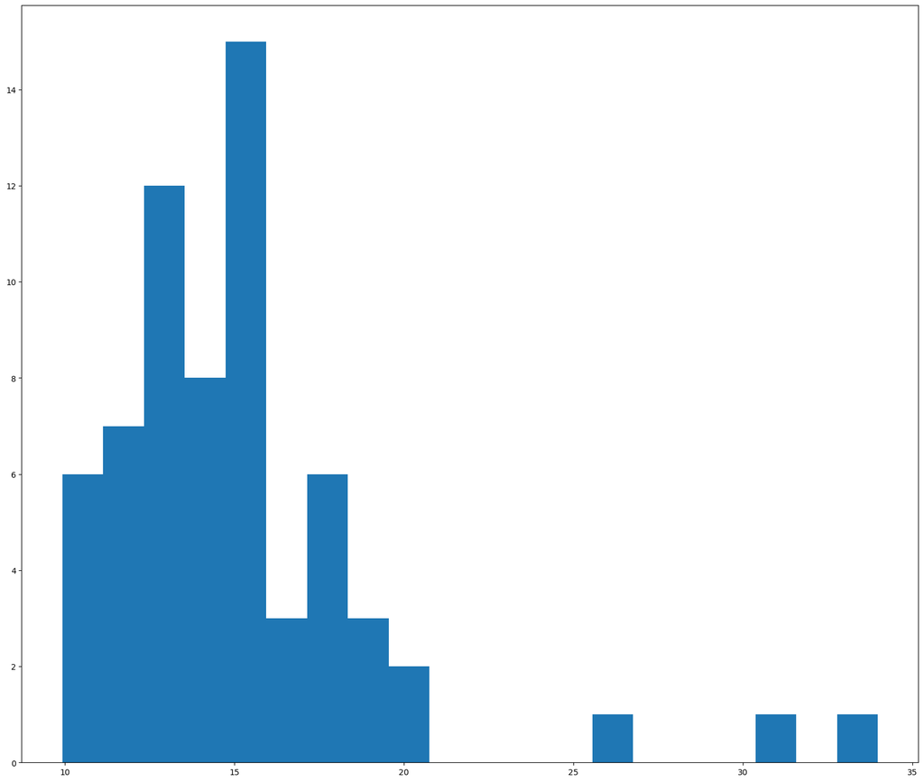

```python
#Sets figure size
plt.figure(figsize = (20, 17))

#Generates histogram
plt.hist(SDD, bins=20)

#Displays plot
plt.show()
```

Above we can see the distribution of SDD is positively skewed meaning most of the data is on the lower end of its spectrum. We see that we get SDD values higher than 25 meters. This is basically crystal clear so we are going to set any SDD value over 25 equal to 25

```python
#Makes every element over 25 equal to 25
for i in range(len(SDD)):
    if SDD.SDD[i] > 25:
        SDD.SDD[i] = 25
```

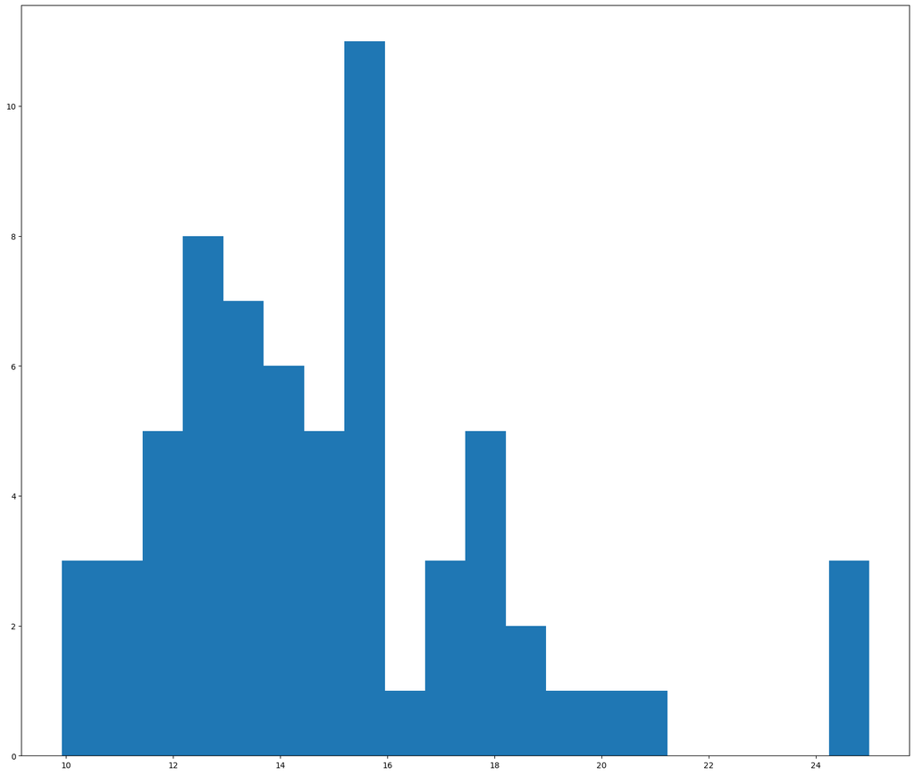

```python
#Sets figure size
plt.figure(figsize = (20, 17))

#Generates histogram
plt.hist(SDD, bins=20)

#Displays plot
plt.show()
```

Now all of our data is gathered, preprocessed, manipulated, and analyzed. Now for the fun part!

We can now look at correlation between our response and predictor variables

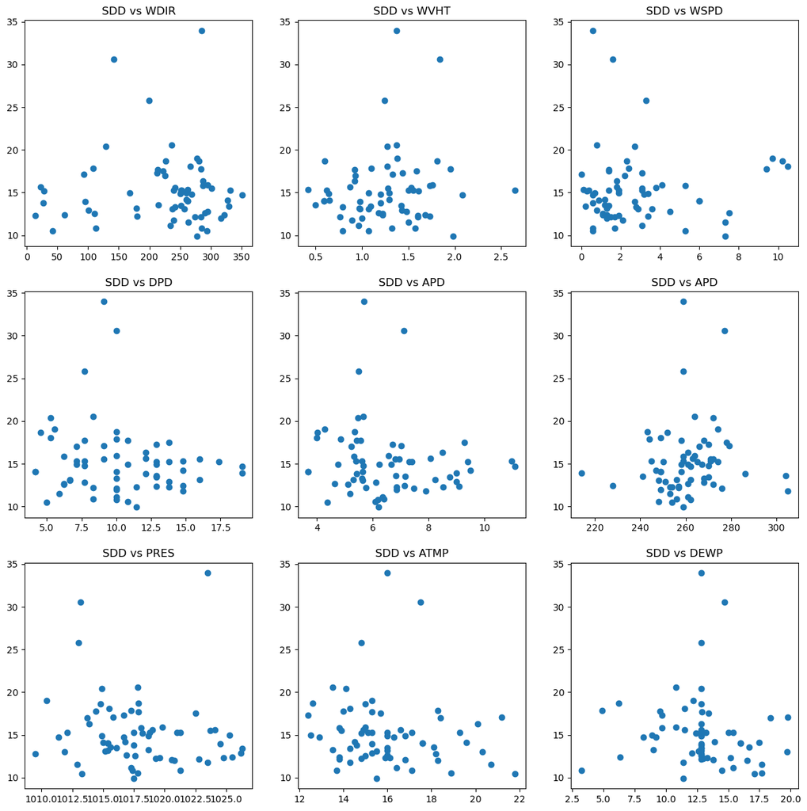

```python
figure(figsize = (15,15))

subplot(3,3,1)
plt.scatter(x = data['WDIR'], y = data['SDD'])
plt.title('SDD vs WDIR')

subplot(3,3,2)
plt.scatter(x = data['WVHT'], y = data['SDD'])
plt.title('SDD vs WVHT')

subplot(3,3,3)
plt.scatter(x = data['WSPD'], y = data['SDD'])
plt.title('SDD vs WSPD')

subplot(3,3,4)
plt.scatter(x = data['DPD'], y = data['SDD'])
plt.title('SDD vs DPD')

subplot(3,3,5)
plt.scatter(x = data['APD'], y = data['SDD'])
plt.title('SDD vs APD')

subplot(3,3,6)
plt.scatter(x = data['MWD'], y = data['SDD'])
plt.title('SDD vs APD')

subplot(3,3,7)
plt.scatter(x = data['PRES'], y = data['SDD'])
plt.title('SDD vs PRES')

subplot(3,3,8)
plt.scatter(x = data['ATMP'], y = data['SDD'])
plt.title('SDD vs ATMP')

subplot(3,3,9)
plt.scatter(x = data['DEWP'], y = data['SDD'])
plt.title('SDD vs DEWP')
```

Based off of these scatterplots there seems to be little correlation between SDD and any predictor variable. Not a good sign for what is to come.

## Machine Learning

```python
from sklearn.model_selection import cross_val_score, train_test_split, GridSearchCV
from sklearn.linear_model import LinearRegression, ElasticNet, Ridge, Lasso
from sklearn.tree import DecisionTreeRegressor
from sklearn.pipeline import Pipeline
from sklearn.metrics import mean_squared_error as MSE
from sklearn.metrics import r2_score
from sklearn.preprocessing import scale, PolynomialFeatures
```

Now we split data into training data , and testing data. Note we don't stratify be SDD. Doing this brings the error "The least populated class in y has only 1 member, which is too few. The minimum number of groups for any class cannot be less than 2." Thus we can conlude that we don't have quite enough samples to stratify using SDD

It is important to split our data into a train and test set so that we can accurately assess how are model will do with data that we have never seen before. If we used all of our data to train our models we could be overfitting the data and have models that perform much worse when they are tested on data we haven't seen before.

```python
X_train, X_test, SDD_train, SDD_test = train_test_split(X, SDD, test_size = 0.2,
                                                      random_state = 2)
```

Since our predictor variables are on such difference scales we are going to scale each column so that it has a mean of 0 and standard deviation of 1.

```python
#Here we scale our predictors
X_train = scale(X_train)
X_test = scale(X_test)
```

### Linear Regression Model

A linear regression model is a model that attempts to find the linear relationship between the predictors and the response. We find the coefficients of the model by solving for the equation that minimizes the residual sum of squares.

We are just going to run a simple linear regression model

```python
#Initialize our model
LinReg = LinearRegression()

#Fit model
LinReg.fit(X_train,SDD_train)
```

```
LinearRegression()
```

Now we want to predict with out model

```python
SDD_pred_lin = LinReg.predict(X_test)
```

Below we have a scatter plot comparing Predicted SDD versus Actuall SDD

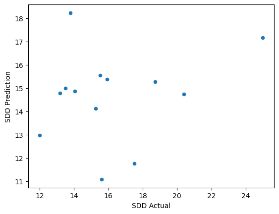

```python
#Create a datafram so that we can plot Actual SDD versus Predicted SDD
linedf = pd.DataFrame()
linedf['SDD Actual'] = SDD_test
linedf['SDD Prediction'] = SDD_pred_lin
linedf.plot.scatter(x = 'SDD Actual', y = 'SDD Prediction')
```

We want to actually see how well our model did so we are going to look at the mean squared error metric and R2 squared value

```python
#Calculates the mean squared error
mse = MSE(SDD_test, SDD_pred_lin)
r2 = r2_score(SDD_test,SDD_pred_lin)
print("Mean Squared Error of Linear Regression Model was: " + str(mse))
print("R2 Squared Value of Linear Regression Model was: " + str(r2))
```

```
Mean Squared Error of Linear Regression Model was: 14.372925287244737
R2 Squared Value of Linear Regression Model was: -0.2499869418895977
```

To test this linear model more we are going to be using cross validation with 5 folds. What this means is that we will be splitting our training data set into five different equal sized subsets. Each time we fit our model we will leave our one of the five subsets and then test with the fifth subset. We will do this five times, leaving out one subset at a time for testing

```python
#Initialize a Linear Regression Model
LinReg_CV = LinearRegression()

#Use cross validation to estimate SDD
LinReg_CV_r2 = np.mean(cross_val_score(LinReg_CV, X_train, SDD_train, cv = 5, scoring ='r2'))
LinReg_CV_mse = np.mean(cross_val_score(LinReg_CV, X_train, SDD_train, cv = 5, scoring='neg_mean_squared_error'))


print("The mean Squared Errors of Linear Regression Model Using Cross Validation is: " + str(LinReg_CV_mse))
print("The mean R2 Squared Values of Linear Regression Model Using Cross Validation is: " + str(LinReg_CV_r2))
```

```
The mean Squared Errors of Linear Regression Model Using Cross Validation is: -18.68389049058172
The mean R2 Squared Values of Linear Regression Model Using Cross Validation is: -1.1778627685328797
```

These don't look like great scores. Hopefully other models perform better

### Lasso Regression Model

Lasso Regression is very similiar to the above linear regression except that it has a penalty that shrinks the coefficient terms. The amout the Lasso penalizes is based off of alpha value that goes from 0 to 1.

In the below code we tune the alpha value so that it minimizes the mean squared error for our training set. We again use cross validation.

```python
alphas = np.linspace(0, 0.9, 36)
LassoReg = Lasso()
alpha_df = { 'alpha': np.linspace(0.01, 0.9, 36)}

LassoReg_Tune = GridSearchCV(LassoReg, alpha_df, scoring='neg_mean_squared_error', cv=5, n_jobs=-1)

results = LassoReg_Tune.fit(X_train, SDD_train)

best_alpha = results.best_params_['alpha']

print('MSE: ' + str(results.best_score_))
print('Config: ' + str(results.best_params_))
```

```
MSE: -10.4566174682388
Config: {'alpha': 0.9}
```

Now we can use our tuned results to fit our model. The alpha value that was chosen was 0.9. This is to be expected because we have seen by our r squared values in the linear regression model, our model does worse than a model that is just a flat line.

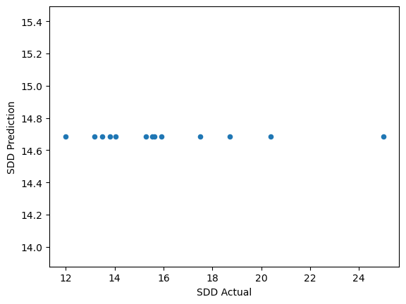

```python
LassoReg = Lasso(alpha = best_alpha)

LassoReg.fit(X_train,SDD_train)

SDD_pred_las = LassoReg.predict(X_test)

#Create a datafram so that we can plot Actual SDD versus Predicted SDD
lassodf = pd.DataFrame()
lassodf['SDD Actual'] = SDD_test
lassodf['SDD Prediction'] = SDD_pred_las
lassodf.plot.scatter(x = 'SDD Actual', y = 'SDD Prediction')
```

```python
#Calculates the mean squared error
mse = MSE(SDD_test, SDD_pred_las)
r2 = r2_score(SDD_test,SDD_pred_las)
print("(When tested on test set) Mean Squared Error of Linear Regression Model was: " + str(mse))
print("(When tested on test set) R2 Squared Value of Linear Regression Model was: " + str(r2))
```

```
(When tested on test set) Mean Squared Error of Linear Regression Model was: 13.759006990917577
(When tested on test set) R2 Squared Value of Linear Regression Model was: -0.19659559402827687
```

This model seems to be just as bad

### Elastic Net Regression Model

Elastic Net Regression combines Ridge and Lasso regression which helps make our model more robust. It chooses the optimal L1 ration to minimize mean squared error.

```python
#We want to set possible tuning paramters
l1_space = np.linspace(0, 1, 30)
param_grid = {'l1_ratio': l1_space}

#Initialize the model
elastic_net = ElasticNet()

#Create a grid to tune paramters
elastic_cv = GridSearchCV(elastic_net, param_grid, cv = 5)

#Fit given model
elastic_cv.fit(X_train, SDD_train)

#Use fitted model to predict
SDD_pred_ela = elastic_cv.predict(X_test)

r2 = r2_score(SDD_test,SDD_pred_ela)
mse = MSE(SDD_test, SDD_pred_ela)

print("Tuned ElasticNet l1 ratio: {}".format(elastic_cv.best_params_))
print('Using Cross Validation and Tuning the best R2 score was: ' + str(elastic_cv.best_score_))
print("(When tested on test set) Mean Squared Error of Linear Regression Model was: " + str(mse))
print("(When tested on test set) R2 Squared Value of Linear Regression Model was: " + str(r2))
```

[output not shown]

Let us plot SDD test versus SDD prediction given to us by tuned elastic net model

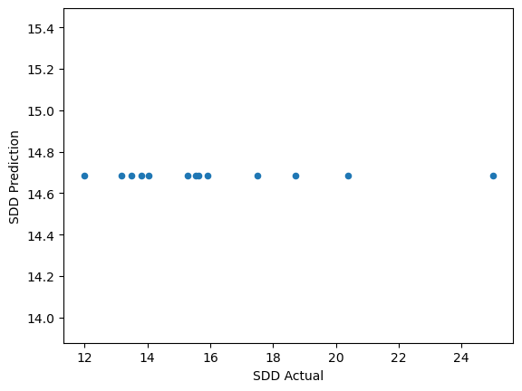

```python
#Create a datafram so that we can plot Actual SDD versus Predicted SDD
Elasticdf = pd.DataFrame()
Elasticdf['SDD Actual'] = SDD_test
Elasticdf['SDD Prediction'] = SDD_pred_ela
Elasticdf.plot.scatter(x = 'SDD Actual', y = 'SDD Prediction')
```

Elastic Net Regression chose A l1 ration of 1. This means it is the same model as lasso regression. This again makes sense since our normal linear model does work than just a flat straight line so our Elastic Net model is going to see that and set every coefficient to 0.

### Decision Tree Regression Model

A decision tree regression model works by splitting the predictor space so that we minimize the variance of each variable. The tree stops when all of its parameters: maxium depth, minimum number of samplesleaf, and maximum number features is met.

```python
DecTre = DecisionTreeRegressor(random_state = 3)
params_dectre = {'max_depth': [3, 4, 5, 6],
             'min_samples_leaf': [0.04, 0.06, 0.08],
             'max_features': [0.2, 0.4,0.6, 0.8]
            }

#Instantiate a 5fold CV grid search object
grid_dectre = GridSearchCV(estimator=DecTre,
                       param_grid=params_dectre,
                       scoring='neg_mean_squared_error',
                       cv=5,
                       n_jobs=-1)

#Fit grid_dectre to the data
grid_dectre.fit(X_train, SDD_train)

best_parameters = grid_dectre.best_params_
print('Using cross validation and tuning the best MSE was: ' + str(grid_dectre.best_score_))
print('Best hyerparameters:\n', best_parameters)
```

```
Using cross validation and tuning the best MSE was: -10.960981077688647
Best hyerparameters:
 {'max_depth': 3, 'max_features': 0.2, 'min_samples_leaf': 0.08}
```

These hyperparameters make sense since we want the lowest depth and least amount of features so we don't box the response into a space that it doesn't actually belong in. The low depth helps us not overfit the data. I would expect if out predictors had more information about our response we would have a max depth greater than 3

```python
DecTre_best_model = grid_dectre.best_estimator_

# Predict the test set labels
SDD_pred_dtr = DecTre_best_model.predict(X_test)

mse = MSE(SDD_test, SDD_pred_dtr)
r2 = r2_score(SDD_test,SDD_pred_dtr)
print("(When tested on test set) Mean Squared Error of Decision Tree Regression Model was: " + str(mse))
print("(When tested on test set) R2 Squared Value of Decision Tree Regression Model was: " + str(r2))
```

[output not shown]

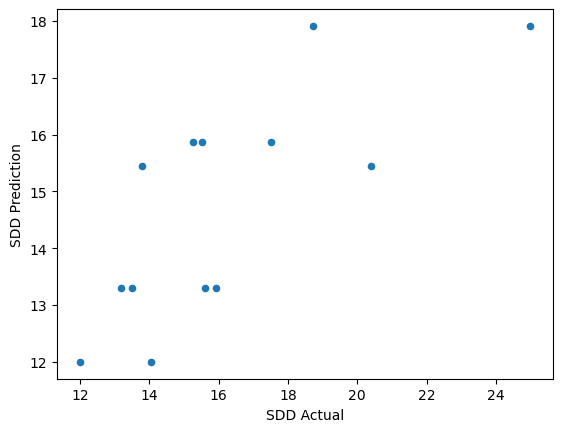

```python
Treedf = pd.DataFrame()
Treedf['SDD Actual'] = SDD_test
Treedf['SDD Prediction'] = SDD_pred_dtr
Treedf.plot.scatter(x = 'SDD Actual', y = 'SDD Prediction')
```

The results of the tree do much better than any other model we have

### Polynomial Regression Model

Polynomial Regression Works similiar to Linear Regression except we also account for any linear relationship one of our predictors taken to the second or third degree could have with our response variable.

```python
#Initialize a polynomial transformation
PolyTran = PolynomialFeatures(degree = 3)

#Transform the predictor variables into a polynomial of degree 3
X_train_poly = PolyTran.fit_transform(X_train)
X_test_poly = PolyTran.transform(X_test)

#Initialize polynomial regression
PolyReg = LinearRegression(normalize = True)

#Use cross validation to estimate SDD
PolyReg_r2 = np.mean(cross_val_score(PolyReg, X_train_poly, SDD_train, cv = 5, scoring ='r2'))
PolyReg_mse = np.mean(cross_val_score(PolyReg, X_train_poly, SDD_train, cv = 5, scoring='neg_mean_squared_error'))


print(" Average Mean Squared Errors of Polynomial Regression Model Using Cross Validation is: " + str(PolyReg_mse))
print("Average R2 Squared Values of Polynomial Regression Model Using Cross Validation is: " + str(PolyReg_r2))


#Fit the data
PolyReg.fit(X_train_poly,SDD_train)

#Predict
SDD_pred_poly = PolyReg.predict(X_test_poly)

#Get scores
mse = MSE(SDD_test, SDD_pred_poly)
r2 = r2_score(SDD_test,SDD_pred_poly)
print("(When tested on test set) Mean Squared Error of Linear Regression Model was: " + str(mse))
print("(When tested on test set) R2 Squared Value of Linear Regression Model was: " + str(r2))
```

```
 Average Mean Squared Errors of Polynomial Regression Model Using Cross Validation is: -28.07199827399084
Average R2 Squared Values of Polynomial Regression Model Using Cross Validation is: -1.8920489490929557
(When tested on test set) Mean Squared Error of Linear Regression Model was: 21.563425796898194
(When tested on test set) R2 Squared Value of Linear Regression Model was: -0.8753315786347531
```

This was expected to be poor since having a polynomial of degree 3 could definitley lead to over fitting

## Best Model

When we look to compare models we have the models with the lowest training MSE to be the Decision Tree Regression Model and the Lasso/Elastic Net Model. We saw above that the Decision Tree Regression Model has an R squared value equal to around 0.345 and a MSE of 7.5. This is much better than the r squared value -0.19 and the MSE of 13.8. Thus we choose the Decision Tree Regression Model as our best model. Let us implement a scatter plot comparing the actual SDD values and the predicted SDD values.

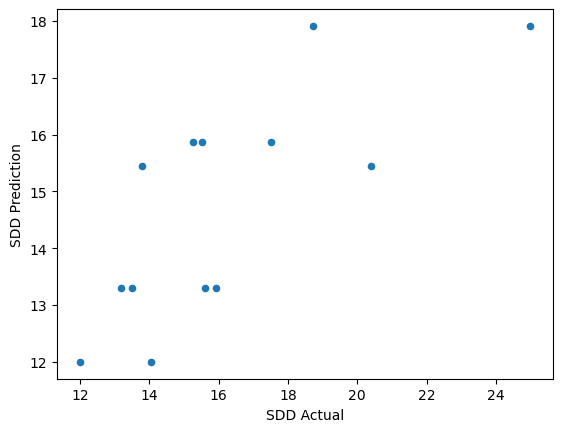

```python
Treedf = pd.DataFrame()
Treedf['SDD Actual'] = SDD_test
Treedf['SDD Prediction'] = SDD_pred_dtr
Treedf.plot.scatter(x = 'SDD Actual', y = 'SDD Prediction')
```

As you can see above the predictions are not very good. But there is somewhat of a correlation which means the predictions are better than random. This is hopeful for when future data that has more information about visibility is gathered.

# Conclusion

After Several Models and no scores that were much better than random, I have come to the conclusion that this data does not hold very much information about SDD. This does not come as too much of a suprise since we are trying to predict water visibility from buoy data. I do believe that there are ways that exist out there that can help us predict water visibility, however from these scores I do not think looking at buoy data is the correct one. Even though no models did very well, the Decision Tree Regression Model did perform the best by far. This leads me to believe that once I collect better data the Decision Tree Regression Model will be the way to go.

## Citations :

Kabiri, K., & Moradi, M. (2016). Landsat-8 imagery to estimate clarity in near-shore coastal waters: Feasibility Study - Chabahar Bay, Iran. Continental Shelf Research, 125, 44–53. https://doi.org/10.1016/j.csr.2016.06.016